## Plotting

We’re going to use a new dataset, `mpg`, included with the `ggplot2` package. To load the data, we’ll start off by loading `ggplot2`:

```r
library(ggplot2)
```

### Question 2:

When data comes with a package, it will usually be documented. You can read the documentation for a dataset (or a function) by running `?<name>` (just like you run any other line of code – either Ctrl + Enter or type it into the console directly).

Try running ?mpg to get more information on our dataset. What does the drv variable describe?

### Question 3:

Using ggplot2, make a scatterplot of hwy vs cyl.

### Question 4:

What happens if you make a scatterplot of class vs drv? Why is the plot not useful?

### Question 5:

What’s gone wrong with this code? Why are the points not blue? Fix it!

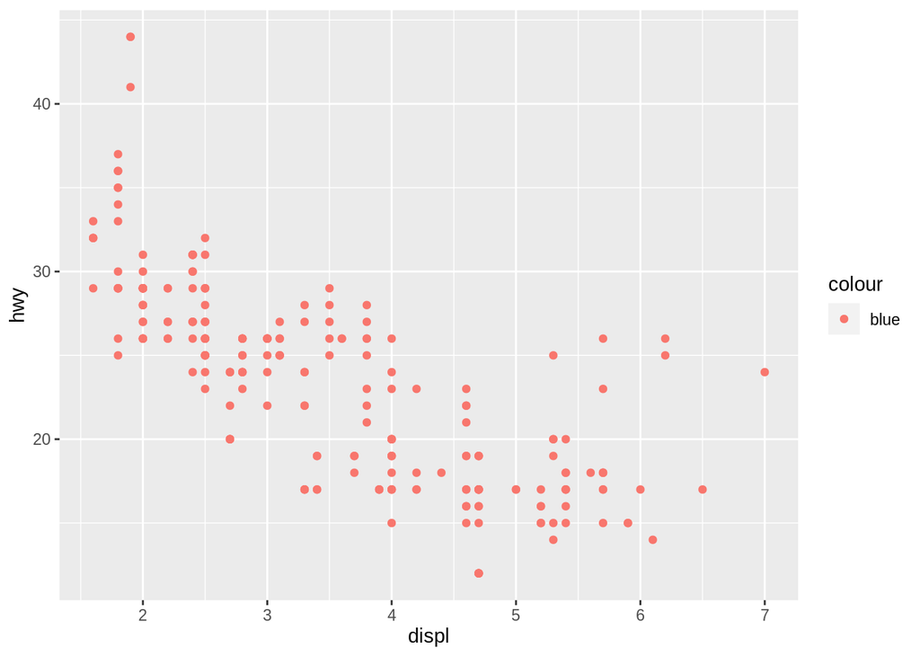

```r
ggplot(data = mpg) +
  geom_point(aes(x = displ, y = hwy, color = "blue"))
```

### Question 6:

Why do these two graphs look the same?

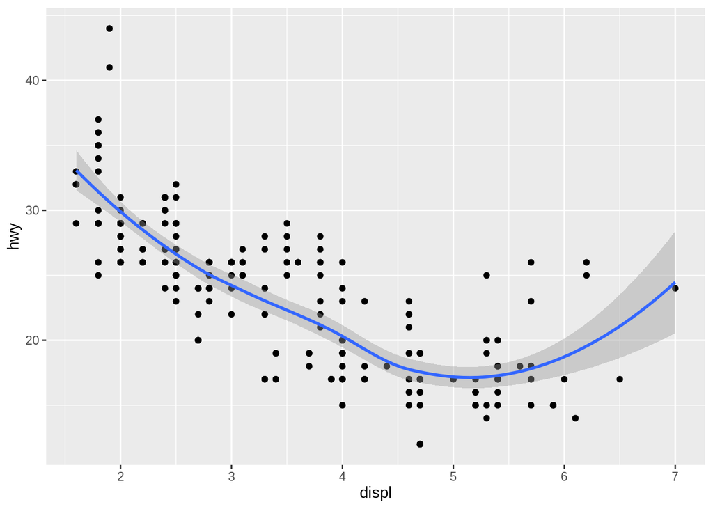

```r
ggplot(data = mpg, aes(x = displ, y = hwy)) +
  geom_point() +
  geom_smooth()
```

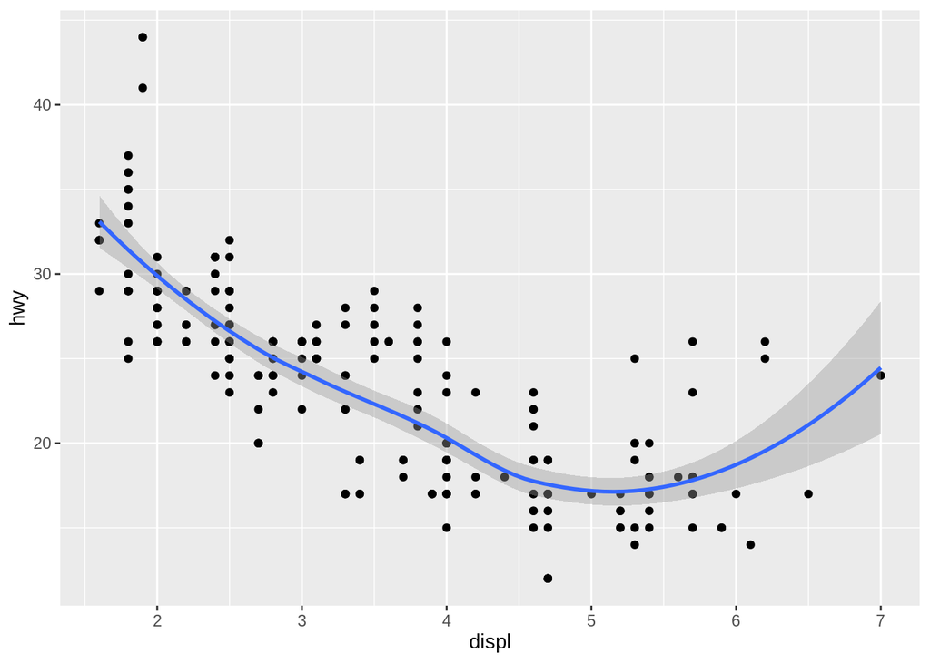

```r
ggplot() +
  geom_point(data = mpg, aes(x = displ, y = hwy)) +
  geom_smooth(data = mpg, aes(x = displ, y = hwy))
```

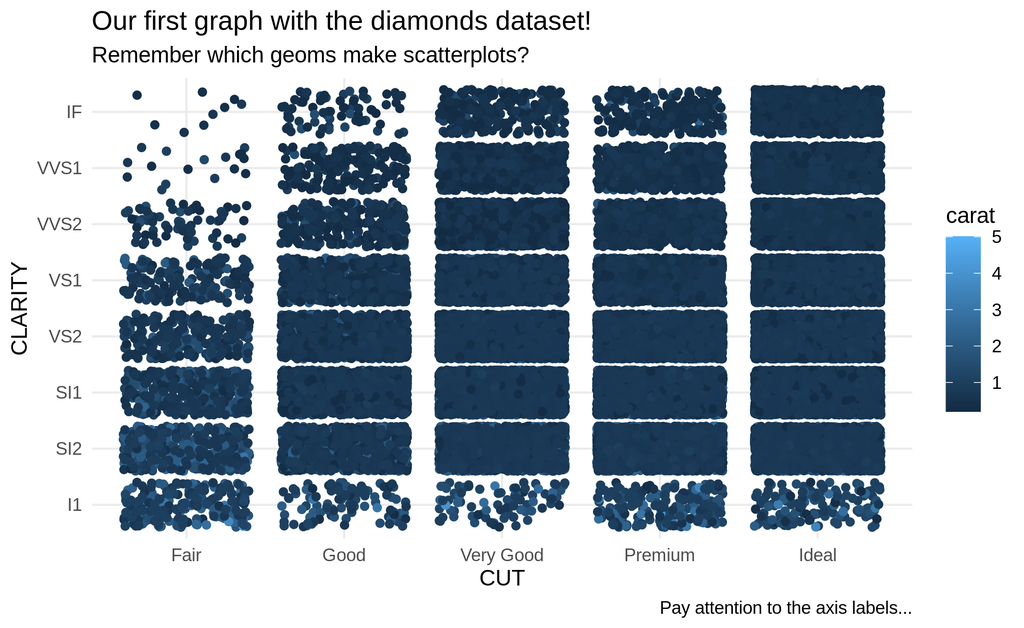

```r
knitr::include_graphics("make_this_graph_1.png")
```

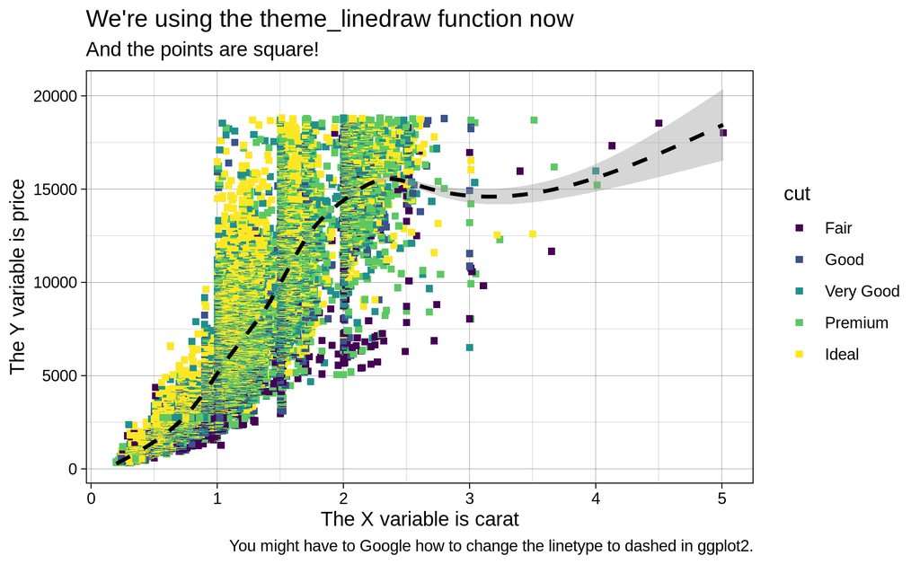

```r
knitr::include_graphics("make_this_graph_2.png")
```

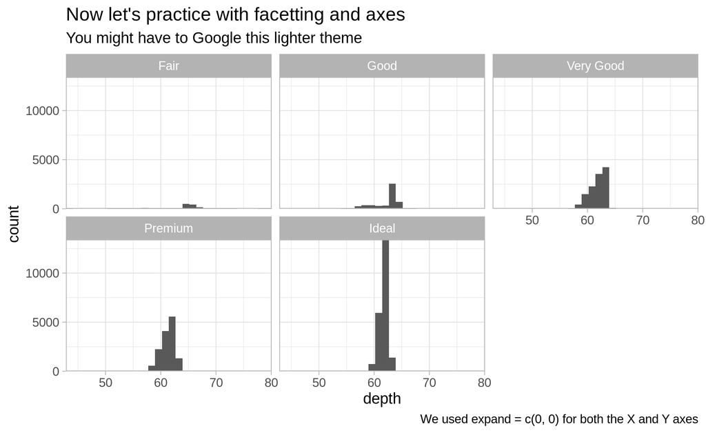

```r
knitr::include_graphics("make_this_graph_3.png")
```

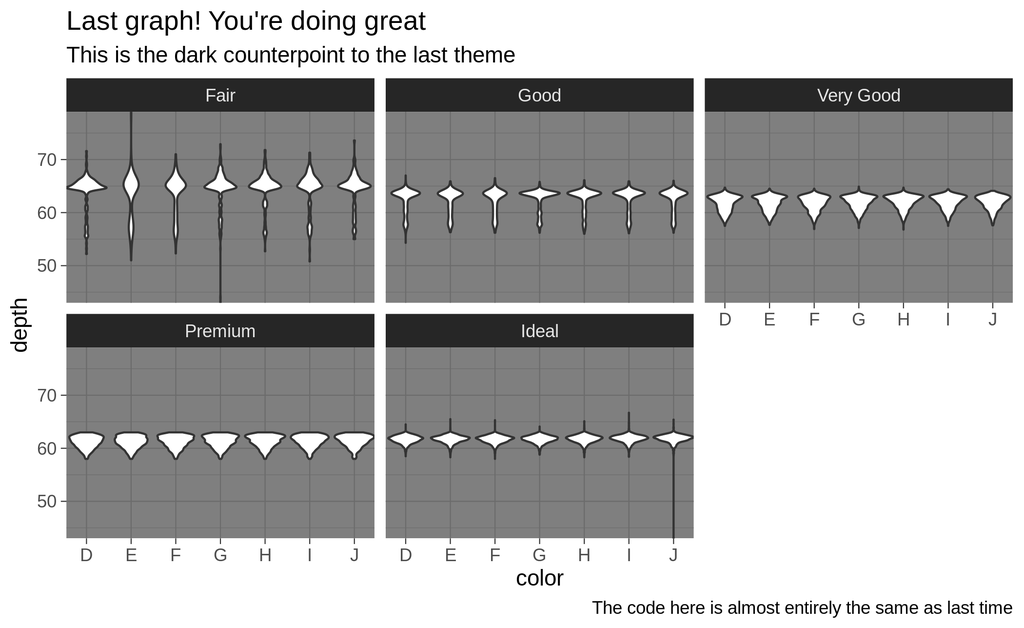

```r
knitr::include_graphics("make_this_graph_4.png")
```